# Image Reformer User's Guide

## Overview

Image Reformer is a utility that converts images into C code for use with MSP430 Graphics Library.

### Why Convert?

Most images are 24 Bits Per Pixel and over 1000 by 1000 pixels. Most MCU displays are 1, 2, 4 or 8 bits per pixel and sizes range from 96x96 to QVGA (320x240). So in order to display the image a color and probably a size conversion is usually needed. Additionally, in order to save image decode time on a low powered MCU, converting the image to C code makes sense for faster display.

### Supported Image Formats

- jpeg
- gif
- png
- bmp
- tif

### Conversion Output Formats

| Color Depth | Max Colors | Compressed | Un-Compressed |
| --- | --- | --- | --- |
| 1 bit per pixel | 2 | Yes RLE4 | Yes |
| 2 bits per pixel | 4 | Yes RLE4 | Yes |
| 4 bits per pixel | 16 | Yes RLE4 | Yes |
| 8 bits per pixel | 256 | Yes RLE8 | Yes |

## Converting an Image

From the Image Reformer main screen press the Open Image Icon or File->Open. This will bring up all the available image files in your root directory. Navigate to the location of the image to load and double click or select and press “Open”.

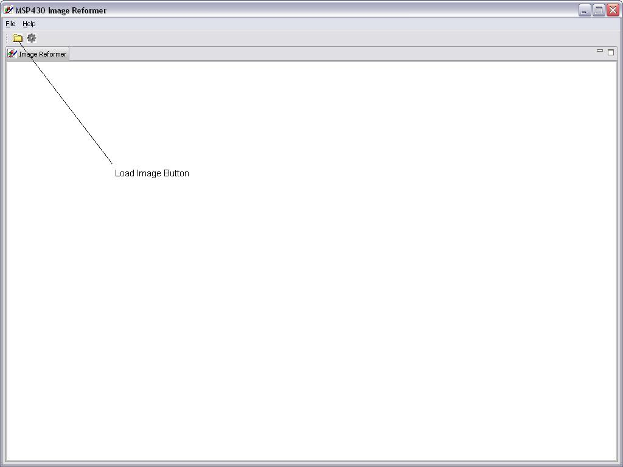

### Types of Conversion

Select the pixel depth conversion and size of the image to generate based on the display parameters you are using.

[figure not shown]

### Compression

Compressed images will use less memory to display and generally display faster but will require a bit more processing. Depending on the requirements compression is available. For 1,2,4 bits per pixel RLE4 compression is used. For 8 bits per pixel, RLE8 is used.

## Generating Output

The final step in converting an image is generating the .c file with the image data for inclusion by Graphics Library. Press the generate button and you will be prompted for a file to save under. This file is based on the input image name with a “.c” extension.In general this file should not need any editing and can be loaded as-is by Graphics Library.